# Dataset for the Summer Olympics from 1896-2012

# Overall, US Men have more medals than the US Women

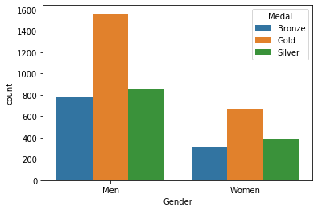

```python
sns.countplot(x="Gender", hue="Medal", data=usa)
```

```python
pd.crosstab(usa['Gender'], usa['Medal'])
```

| Medal Gender | Bronze | Gold | Silver |
| --- | --- | --- | --- |
| Men | 785 | 1562 | 861 |
| Women | 313 | 673 | 391 |

```python
pd.crosstab(usa['Gender'], usa['Sport'])
```

| Sport Gender | Aquatics | Archery | Athletics | Baseball | Basketball | Boxing | Canoe / Kayak | Cycling | Equestrian | Fencing | ... | Shooting | Skating | Softball | Taekwondo | Tennis | Triathlon | Tug of War | Volleyball | Weightlifting | Wrestling |
| --- | --- | --- | --- | --- | --- | --- | --- | --- | --- | --- | --- | --- | --- | --- | --- | --- | --- | --- | --- | --- | --- |
| Men | 644 | 38 | 797 | 68 | 210 | 109 | 15 | 50 | 85 | 37 | ... | 177 | 0 | 0 | 5 | 28 | 0 | 15 | 56 | 41 | 125 |
| Women | 540 | 17 | 197 | 0 | 108 | 2 | 6 | 16 | 36 | 15 | ... | 13 | 1 | 60 | 3 | 26 | 1 | 0 | 58 | 2 | 4 |

2 rows × 34 columns

# Interesting Find:

> - Team Sports: every athlete on that team gets a medal (Ex. Basketball, 12 winners)

```python
usa12 = usa.iloc[4330:,]
usa12[usa12['Sport'] == 'Basketball']
```

|  | Year | City | Sport | Discipline | Athlete | Country | Gender | Event | Medal |
| --- | --- | --- | --- | --- | --- | --- | --- | --- | --- |
| 29796 | 2012 | London | Basketball | Basketball | ANTHONY, Carmelo | USA | Men | Basketball | Gold |
| 29797 | 2012 | London | Basketball | Basketball | BRYANT, Kobe | USA | Men | Basketball | Gold |
| 29798 | 2012 | London | Basketball | Basketball | CHANDLER, Tyson | USA | Men | Basketball | Gold |
| 29799 | 2012 | London | Basketball | Basketball | DAVIS, Anthony | USA | Men | Basketball | Gold |
| 29800 | 2012 | London | Basketball | Basketball | DURANT, Kevin | USA | Men | Basketball | Gold |
| 29801 | 2012 | London | Basketball | Basketball | HARDEN, James | USA | Men | Basketball | Gold |
| 29802 | 2012 | London | Basketball | Basketball | IGUODALA, Andre | USA | Men | Basketball | Gold |
| 29803 | 2012 | London | Basketball | Basketball | JAMES, Lebron | USA | Men | Basketball | Gold |
| 29804 | 2012 | London | Basketball | Basketball | LOVE, Kevin | USA | Men | Basketball | Gold |
| 29805 | 2012 | London | Basketball | Basketball | PAUL, Chris | USA | Men | Basketball | Gold |
| 29806 | 2012 | London | Basketball | Basketball | WESTBROOK, Russell | USA | Men | Basketball | Gold |
| 29807 | 2012 | London | Basketball | Basketball | WILLIAMS, Deron | USA | Men | Basketball | Gold |
| 29832 | 2012 | London | Basketball | Basketball | AUGUSTUS, Seimone | USA | Women | Basketball | Gold |
| 29833 | 2012 | London | Basketball | Basketball | BIRD, Sue | USA | Women | Basketball | Gold |
| 29834 | 2012 | London | Basketball | Basketball | CASH, Swin | USA | Women | Basketball | Gold |
| 29835 | 2012 | London | Basketball | Basketball | CATCHINGS, Tamika | USA | Women | Basketball | Gold |
| 29836 | 2012 | London | Basketball | Basketball | CHARLES, Tina | USA | Women | Basketball | Gold |
| 29837 | 2012 | London | Basketball | Basketball | FOWLES, Sylvia | USA | Women | Basketball | Gold |
| 29838 | 2012 | London | Basketball | Basketball | JONES, Asjha | USA | Women | Basketball | Gold |
| 29839 | 2012 | London | Basketball | Basketball | MCCOUGHTRY, Angel | USA | Women | Basketball | Gold |
| 29840 | 2012 | London | Basketball | Basketball | MOORE, Maya | USA | Women | Basketball | Gold |
| 29841 | 2012 | London | Basketball | Basketball | PARKER, Candace | USA | Women | Basketball | Gold |
| 29842 | 2012 | London | Basketball | Basketball | TAURASI, Diana | USA | Women | Basketball | Gold |
| 29843 | 2012 | London | Basketball | Basketball | WHALEN, Lindsay | USA | Women | Basketball | Gold |

[figure not shown]

```python
plt.title('USA: Men vs Women Olypians')

usa['Gender'].value_counts().plot(kind='pie', figsize = (20, 10), colors=['orange', 'purple'])
```

# Statistical Analysis of the data:

## Missing data:

> - Ages of Athletes (youngest, oldest, average age)
> - Timed trials (compare over the years)
> - Height and Weight (does this affect winning?)
> - All Olympic athletes, not just the winners (Could see how many repetitive athletes there are, how many athletes are from each Country, etc)
> - Winning Athletes: All competetions they competed in (See how many medals won to number of competitions competed in)

# Conclusions: